# Visualização de dados

Fellipe Gomes

5 de dezembro de 2017

# Análise exploratória dos dados

## ggplot2

## GGally

Carregando o pacote:

```r
suppressMessages(library(GGally))
```

### `GGally::ggcoef`

O objetivo da função `GGally::ggcoef` é traçar rapidamente os coeficientes de um modelo.

Para um modelo linear:

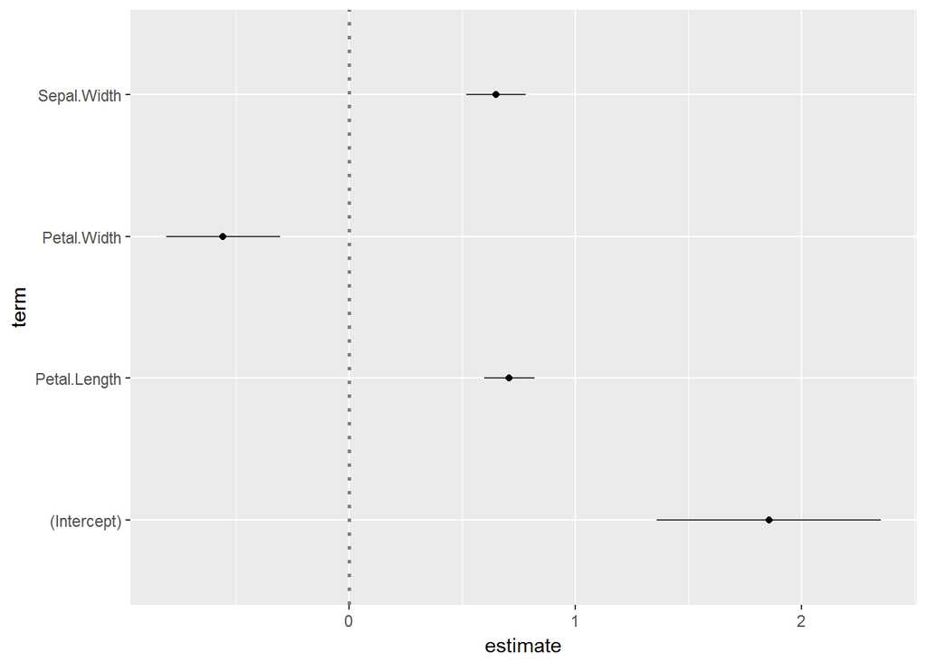

```r
reg <- lm(Sepal.Length ~ Sepal.Width + Petal.Length + Petal.Width, data = iris)
ggcoef(reg)
```

Para um modelo logístico podemos utilizar o argumento `exponentiate = TRUE` e além disso, somos capazes de fazer diversas alterações no gráfico utilizando o `ggcoef()` veja alguns exemplo de argumentos que podem ser usados para personalizar como barras de erro e a linha vertical são plotadas:

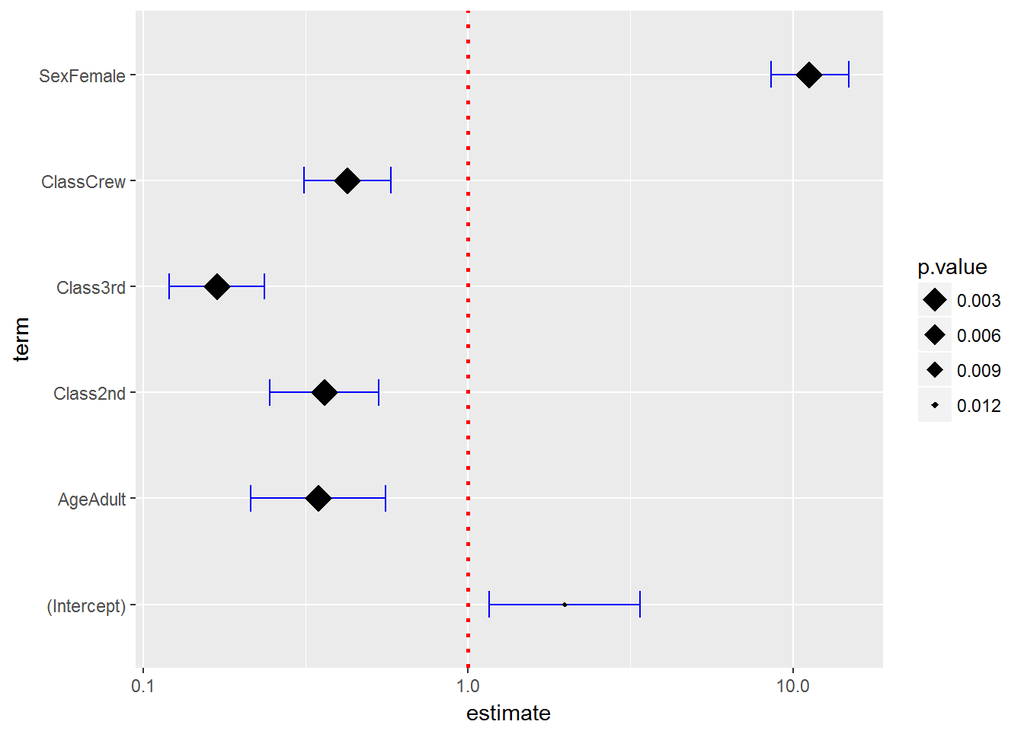

```r
#Ajustando o modelo:
d <- as.data.frame(Titanic)
log.reg <- glm(Survived ~ Sex + Age + Class, family = binomial, data = d, weights = d$Freq)

#Elaborando o gráfico
ggcoef(
  log.reg,                      #O modelo a ser conferido
  exponentiate = TRUE,          #Para avaliar o modelo logístico
  vline_color = "red",          #Reta em zero
  #vline_linetype =  "solid",   #Altera a linha de referência
  errorbar_color = "blue",      #Cor da barra de erros
  errorbar_height = .25,
  shape = 18,                   #Altera o formato dos pontos centrais
  #size=3,                      #Altera o tamanho do ponto
  color="black",                #Altera a cor do ponto
  mapping = aes(x = estimate, y = term, size = p.value))+
  scale_size_continuous(trans = "reverse") #Essa linha faz com que inverta o tamanho
```

### `GGally::ggduo`

O objetivo desta função é exibir dois dados agrupados em uma matriz de plotagem. Isso é útil para análise de correlação canônica, análise de séries temporais múltiplas e análise de regressão.

Os dados do exemplo apresentados aqui podem ser encontrados neste [link](http://www.stats.idre.ucla.edu/r/dae/canonical-correlation-analysis)

```r
data(psychademic)
head(psychademic)
```

```
##   locus_of_control self_concept motivation read write math science    sex
## 1            -0.84        -0.24          4 54.8  64.5 44.5    52.6 female
## 2            -0.38        -0.47          3 62.7  43.7 44.7    52.6 female
## 3             0.89         0.59          3 60.6  56.7 70.5    58.0   male
## 4             0.71         0.28          3 62.7  56.7 54.7    58.0   male
## 5            -0.64         0.03          4 41.6  46.3 38.4    36.3 female
## 6             1.11         0.90          2 62.7  64.5 61.4    58.0 female
```

```r
psych_variables <- attr(psychademic, "psychology")
academic_variables <- attr(psychademic, "academic")
```

```r
ggduo(
  psychademic, psych_variables, academic_variables,
  types = list(continuous = "smooth_lm"),
  title = "Correlação entre as variáveis psicológicas e academicas",
  xlab = "Psicológicos",
  ylab = "Academicas"
)
```

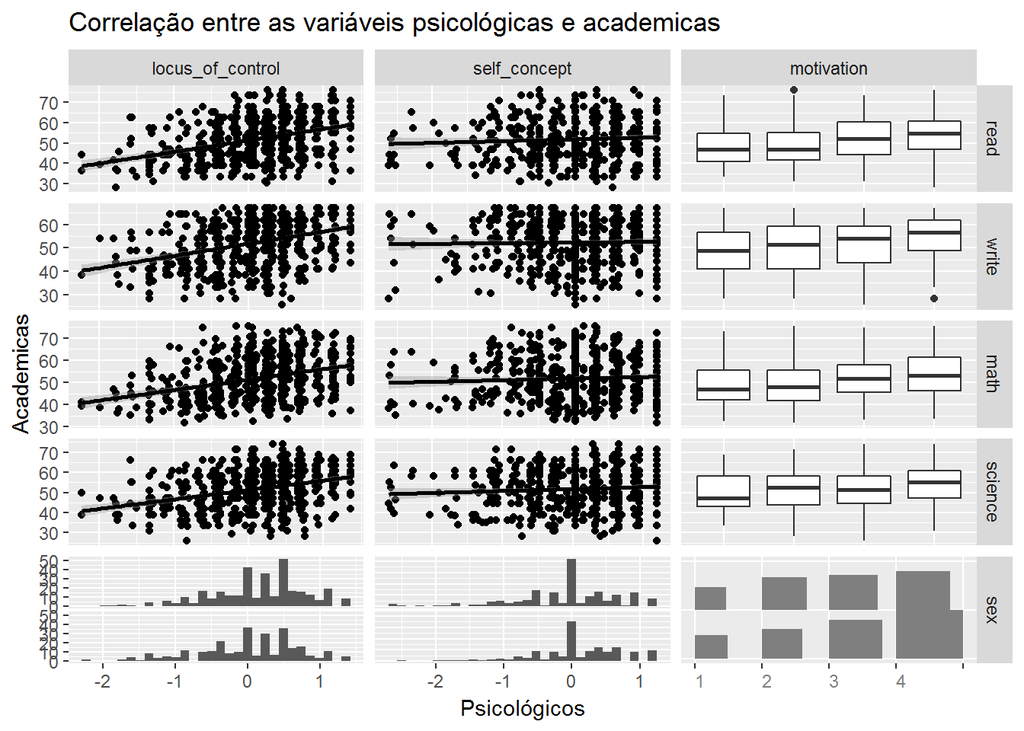

Uma vez que o `ggduo` não tem uma seção superior para exibir os valores de correlação, podemos usar uma função personalizada para adicionar a informação nas parcelas contínuas.

Portanto:

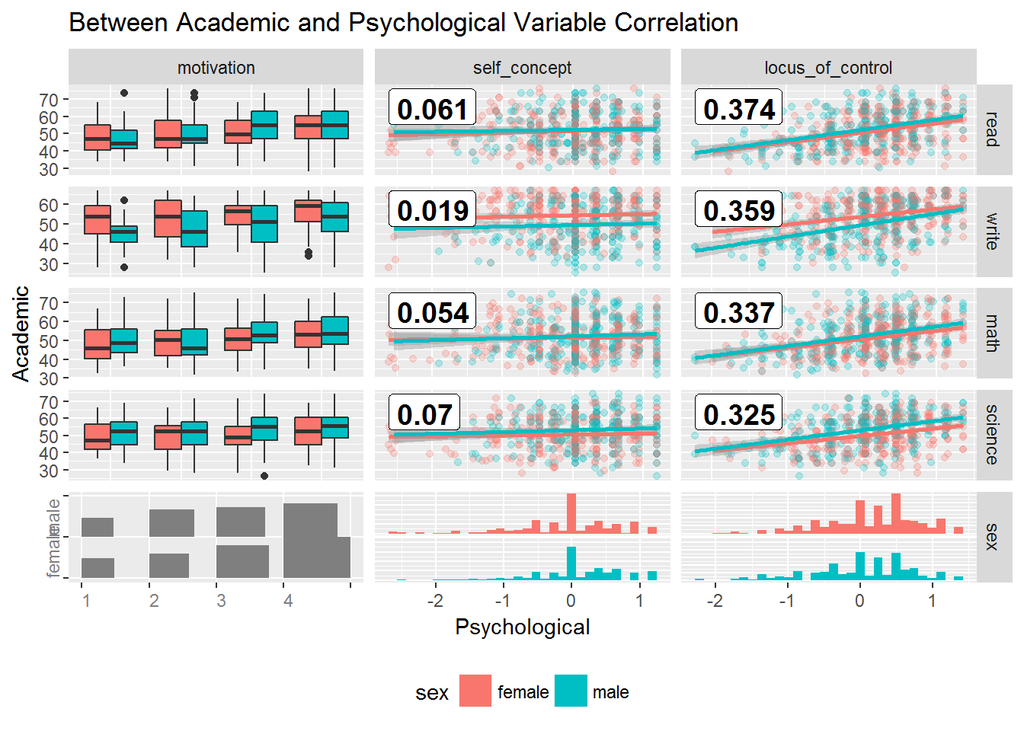

```r
ggduo(
  psychademic, rev(psych_variables), academic_variables,
  mapping = aes(color = sex),
  types = list(continuous = wrap(lm_with_cor, alpha = 0.25)),
  showStrips = FALSE,
  title = "Between Academic and Psychological Variable Correlation",
  xlab = "Psychological",
  ylab = "Academic",
  legend = c(5,2)
) +
  theme(legend.position = "bottom")
```

Para avaliar resíduos de uma regressão:

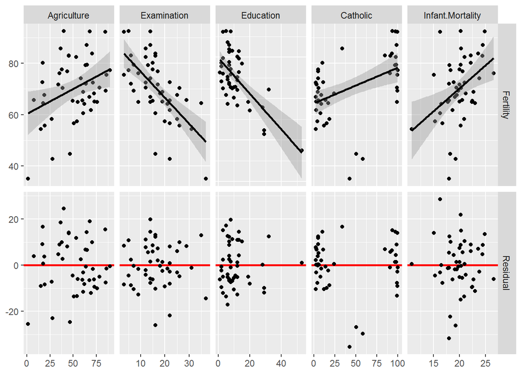

```r
dados <- datasets::swiss

# Criando uma coluna "fake":
dados$Residual <- seq_len(nrow(dados))

# Calculando todos os resíduos que serão exibidos:
colunas=2:6  #Informe as colunas que contem as variaveis explanatorias
residuals <- lapply(dados[colunas], function(x) {
  summary(lm(Fertility ~ x, data = dados))$residuals
})
# Calculando um intervalo constante para todos os resíduos
y_range <- range(unlist(residuals))

# Função modificada para mostrar os resíduos:

lm_or_resid <- function(data, mapping, ..., line_color = "red", line_size = 1) {
  if (as.character(mapping$y) != "Residual") {
    return(ggally_smooth_lm(data, mapping, ...))
  }

  # Criando os resíduos para apresentar:
  resid_data <- data.frame(
    x = data[[as.character(mapping$x)]],
    y = residuals[[as.character(mapping$x)]]
  )

  ggplot(data = data, mapping = mapping) +
    geom_hline(yintercept = 0, color = line_color, size = line_size) +
    ylim(y_range) +
    geom_point(data = resid_data, mapping = aes(x = x, y = y), ...)

}

# Plote os dados:
ggduo(
  dados,
  2:6, c(1,7),
  types = list(continuous = lm_or_resid)
)
```

### `GGally::ggnostic`

o `ggnostic` é um wrapper de exibição para `ggduo` que exibe diagnósticos de modelo completo para cada variável explicativa dada.

Por padrão, o ggduo exibe os valores residuais, o sigma do modelo de saída-one-out, os pontos de alavanca e a distância de Cook em relação a cada variável explicativa.

As linhas da matriz de plotagem podem ser expandidas para incluir valores ajustados, erro padrão dos valores ajustados, resíduos padronizados e qualquer uma das variáveis de resposta.

Se o modelo for um modelo linear, as estrelas são adicionadas de acordo com o significado anova de cada variável explicativa.

A maioria das parcelas diagnósticas contêm linhas de referência para ajudar a determinar se o modelo está adequadamente instalado

Olhando para os conjuntos de dados do conjunto de dados `state.x77` ajustaremos um modelo de regressão múltipla para a expectativa de vida.

```r
#Dados que serão utilizados no exemplos:
state <- as.data.frame(state.x77)
#Arrumando o nome das variaveis:
colnames(state)[c(4, 6)] <- c("Life.Exp", "HS.Grad")
# Ajustando o modelo completo:
model <- lm(Life.Exp ~ ., data = state)
# Executando o stepwise para encontrar o melhor ajuste
model <- step(model, trace = FALSE)
```

Executando o diagnóstico deste modelo:

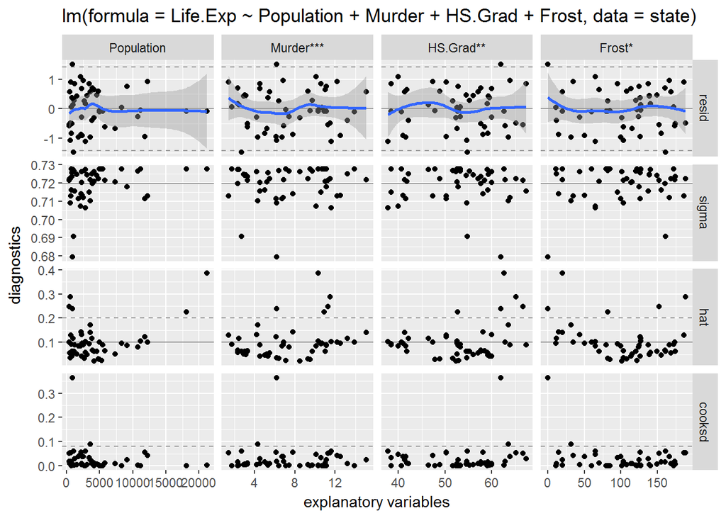

```r
# look at model diagnostics
ggnostic(model)
```

Para acessar as variáveis influentes do modelo:

```r
summary(influence.measures(model))
```

```
## Potentially influential observations of
##   lm(formula = Life.Exp ~ Population + Murder + HS.Grad + Frost,      data = state) :
##
##            dfb.1_ dfb.Pplt dfb.Mrdr dfb.HS.G dfb.Frst dffit   cov.r
## Alaska      0.41   0.18    -0.40    -0.35    -0.16    -0.50    1.36_*
## California  0.04  -0.09     0.00    -0.04     0.03    -0.12    1.81_*
## Hawaii     -0.03  -0.57    -0.28     0.66    -1.24_*   1.43_*  0.74
## Nevada      0.40   0.14    -0.42    -0.29    -0.28    -0.52    1.46_*
## New York    0.01  -0.06     0.00     0.00    -0.01    -0.07    1.44_*
##            cook.d hat
## Alaska      0.05   0.25
## California  0.00   0.38_*
## Hawaii      0.36   0.24
## Nevada      0.05   0.29
## New York    0.00   0.23
```

Vejamos então umu exemplo de matriz de matriz de diagnóstico completo.

```r
#Ajustando um modelo de exemplo:
flea_model <- step(lm(head ~ ., data = flea), trace = FALSE)
```

Diagnóstico completo:

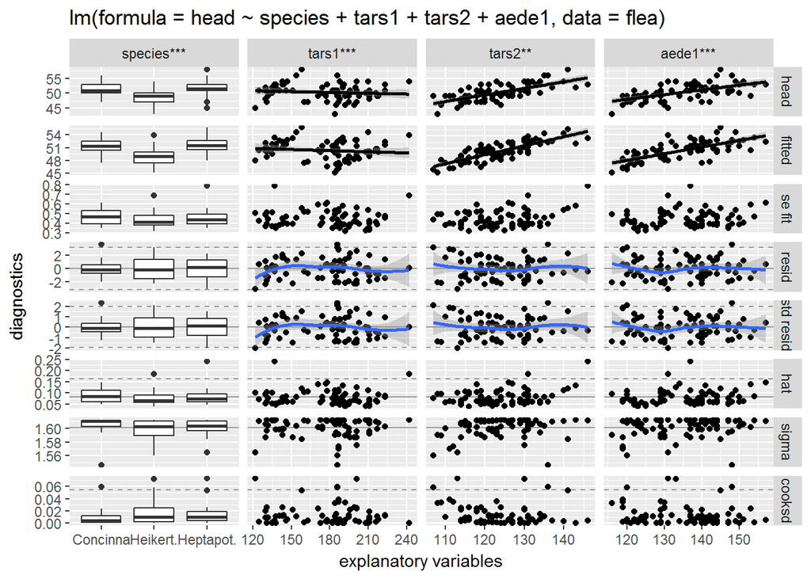

```r
# default output
ggnostic(flea_model,
 #        mapping = ggplot2::aes(color = species),  #Para colorir segundo um fator
         columnsY = c("head", ".fitted", ".se.fit", ".resid", ".std.resid", ".hat", ".sigma", ".cooksd"),
        continuous = list(default = ggally_smooth, .fitted = ggally_smooth)
)
```

### `GGally::ggpairs`

`ggpairs` é uma forma especial de uma ggmatrix que produz uma comparação pairwise de dados multivariados. Por padrão, o ggpairs fornece duas comparações diferentes de cada par de colunas e exibe a densidade ou a contagem da variável respectiva ao longo da diagonal. Com diferentes configurações de parâmetros, a diagonal pode ser substituída pelos valores do eixo e rótulos variáveis.

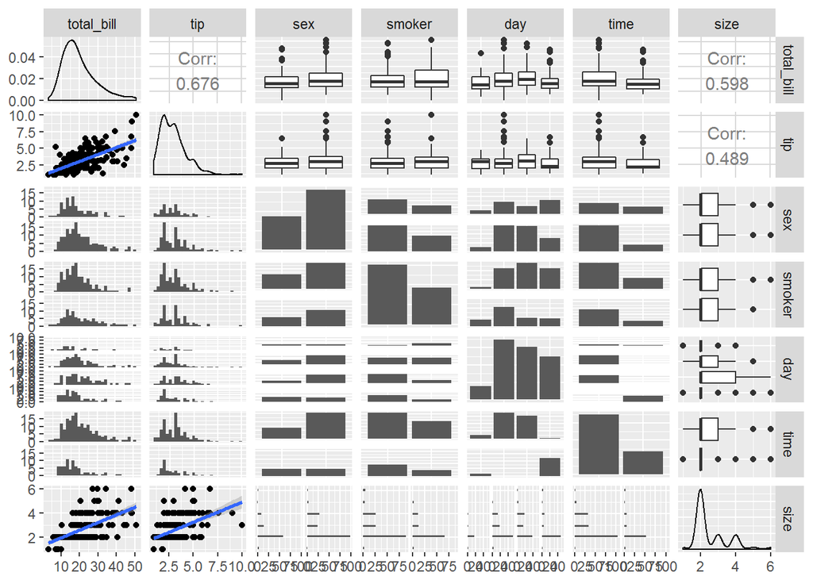

```r
#Funcao de correlacoes
my_fn <- function(data, mapping, method="lm", ...){
  p <- ggplot(data = data, mapping = mapping) +
    geom_point() +
    geom_smooth(method=method, ...)
  p
}
data(tips, package = "reshape")
#Correlaçoes cruzadas
ggpairs(tips, lower = list(continuous = my_fn))
```

### `GGally::ggscatmat`

A principal função é `ggscatmat`. É semelhante a ggpairs, mas funciona apenas para dados multivariados puramente numéricos.

É mais rápido que ggpairs, porque é necessário fazer menos escolhas.

Ele cria uma matriz com diagramas de dispersão na diagonal inferior, densidades na diagonal e correlações escritas na diagonal superior.

A sintaxe é inserir o conjunto de dados, as colunas que deseja traçar, uma coluna de cores e um nível alfa.

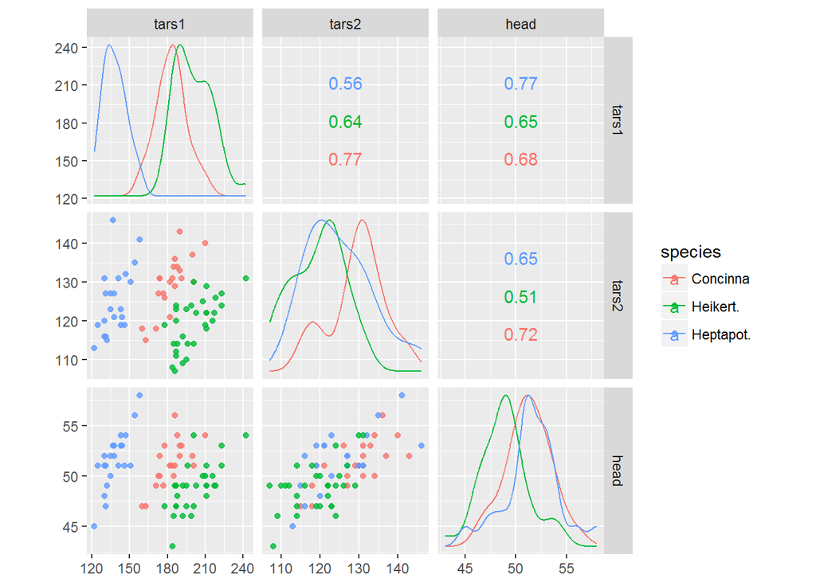

```r
data(flea)
ggscatmat(flea, columns = 2:4, color="species", alpha=0.8)
```